# Test - Data Science - BNDMR

## Installation des packages

```r
install.packages("reshape2")
```

```
Error in install.packages : Updating loaded packages
```

## Chargement des packages

```r
# Charger les librairies
library(dplyr)
library(rmarkdown)
library(ggplot2)
library(lubridate)
library(stats)
library(reshape2)
library(cowplot)
library(RColorBrewer)
```

## Objectif

Dans cette étude, nous nous intéresserons à : - étudier les données sur les patients hospitalisées pour l’*EB*; - évaluer l’impact du type *EB* sur l’évolution de la concentration de plomb chez les patients traités avec le même médicaments

## Exploration des données

### Présentation des tables

Pour réaliser notre étude, la filière nous a confiée trois tables : - *patients* : données démographiques des patients - *diagnostics* : données sur les diagnostics des patients - *obs_plomb* : données sur l’état des patients traités par le plomb durant 6 semaines

```r
# Charger les données
diagnostics <- readRDS("~/Documents/test-BNDMR/diagnostics.RDS")
obs_plomb <- readRDS("~/Documents/test-BNDMR/obs_plomb.RDS")
patients <- readRDS("~/Documents/test-BNDMR/patients.RDS")
```

```r
# Caractéristique des tables
str(diagnostics)
```

```
'data.frame':   162 obs. of  5 variables:
 $ idmr         : chr  "3263373164" "3433643965" "3335356165" "6136353339" ...
 $ diagnostic   : chr  "251393" "251393" "257" "79403" ...
 $ level        : chr  "CON" "UNK" "PRO" NA ...
 $ inclusion    : Date, format: "2017-06-14" "2019-06-18" "2019-07-21" "2019-05-10" ...
 $ last_activity: Date, format: "2019-02-25" "2020-04-09" "2021-04-01" "2021-09-27" ...
```

```r
str(obs_plomb)
```

```
'data.frame':   100 obs. of  5 variables:
 $ idmr: chr  "6464303430" "3232333238" "3730396166" "3964656633" ...
 $ W0  : num  30.8 26.5 25.8 24.7 20.4 20.4 28.6 33.7 19.7 31.1 ...
 $ W1  : num  26.9 14.8 23 24.5 2.8 5.4 20.8 31.6 14.9 31.2 ...
 $ W4  : num  25.8 19.5 19.1 22 3.2 4.5 19.2 28.5 15.3 29.2 ...
 $ W6  : num  23.8 21 23.2 22.5 9.4 11.9 18.4 25.1 14.7 30.1 ...
```

```r
str(patients)
```

```
'data.frame':   184 obs. of  5 variables:
 $ birthyear : num  1957 1971 1948 1961 1972 ...
 $ housenum  : Factor w/ 486 levels "0","100","1001",..: 74 447 350 226 449 429 41 362 137 243 ...
 $ streetname: Factor w/ 482 levels " 100th ave"," 107th ave",..: 191 406 348 15 217 316 225 26 255 169 ...
 $ idmr      : chr  "3263373164" "3433643965" "3335356165" "6136353339" ...
 $ alive     : num  1 1 1 1 1 1 1 1 1 1 ...
```

```r
# Taille des tables
dim(diagnostics)
```

```
[1] 162   5
```

```r
dim(obs_plomb)
```

```
[1] 100   5
```

```r
dim(patients)
```

```
[1] 184   5
```

#### Description des tables

La table *patients* possède les variable suivantes : - *birthyear* : année de naissance du patient; - *housenum* : numéro de la maison du patient; - *streetname* : nom de la rue du patient; - *idmr* : identifiant du patient; - *alive* : statut vital du patient;

La table *diagnostics* possède les variables suivantes : - *idmr* : identifiant du patient; - *diagnostics* : type de *EB* atteint par le patient; - *level* - *inclusion* : date de début de l’hospitalisation du patient; - *last_activity* : dernière date de l’activité du patient;

La table *obs_plomb* possède les variables suivants : - *idmr* : identifiant du patient; - *WO* : pas de traitement - *W1* : première semaine du traitement de plomb - *W4* : quatrième semaine du traitement de plomb - *W6* : dernière semaine du traitement de plomb

#### Données démographiques sur les patients hospitaliéses pour l’EB

```r
patients_EB <-left_join(patients, diagnostics, by="idmr")
head(patients_EB)
```

|  | birthyear | housenum | streetname | idmr | alive | diagnostic | level | inclusion | last_activity |
| --- | --- | --- | --- | --- | --- | --- | --- | --- | --- |
| 1 | 1957 | 1564 | fairview ct | 3263373164 | 1 | 251393 | CON | 2017-06-14 | 2019-02-25 |
| 2 | 1971 | 6909 | shepherd ave apt 4 | 3433643965 | 1 | 251393 | UNK | 2019-06-18 | 2020-04-09 |
| 3 | 1971 | 6909 | shepherd ave apt 4 | 3433643965 | 1 | 305 | UNK | 2019-06-18 | 2020-04-09 |
| 4 | 1948 | 4547 | piedmont ave | 3335356165 | 1 | 257 | PRO | 2019-07-21 | 2021-04-01 |
| 5 | 1961 | 30436 | 49th ave | 6136353339 | 1 | 79403 | NA | 2019-05-10 | 2021-09-27 |
| 6 | 1972 | 6967 | glenwood dr | 6133616339 | 1 | 158684 | UNK | 2018-04-26 | 2021-12-07 |

#### Nettoyage des données

##### Données démographiques des patients hospitalisés pour l’EB

On commence par identifier les valeurs manquantes et les supprimer.

```r
# Vérification des valeurs manquantes
any(is.na(patients_EB))
```

```
[1] TRUE
```

```r
# Nombre de valeurs manquantes pour chaque variable
colSums(is.na(patients_EB))
```

```
    birthyear      housenum    streetname          idmr         alive    diagnostic         level     inclusion
            0             1             0             0             0            23            63            23
last_activity
           23
```

```r
# Identifier les lignes avec des valeurs manquantes
rows_with_missing_values <- patients_EB[apply(patients_EB[, c('diagnostic', 'inclusion', 'last_activity')], 1, function(x) any(is.na(x))), ]
print(head(rows_with_missing_values, 10))
```

|  | birthyear | housenum | streetname | idmr | alive | diagnostic | level | inclusion | last_activity |
| --- | --- | --- | --- | --- | --- | --- | --- | --- | --- |
| 13 | 1972 | 1470 | james ave | 3438626264 | 1 | NA | NA |  |  |
| 31 | 1995 | 16665 | buren pl | 3634636631 | 1 | NA | NA |  |  |
| 35 | 1995 | 3294 | deauville park ct | 6466633635 | 1 | NA | NA |  |  |
| 46 | 1941 | 3332 | altamont ave | 3830336666 | 1 | NA | NA |  |  |
| 47 | 1936 | 6029 | clarke st | 6531336463 | 1 | NA | NA |  |  |
| 49 | 1986 | 3646 | longridge rd | 3932383061 | 0 | NA | NA |  |  |
| 68 | 1981 | 1841 | alvarado niles rd apt 211 | 6638373736 | 1 | NA | NA |  |  |
| 81 | 1971 | 6378 | central ave apt d | 6533393465 | 1 | NA | NA |  |  |
| 90 | 1918 | 5943 | san luis rd | 3537363332 | 1 | NA | NA |  |  |
| 93 | 1969 | 3623 | prospect st apt c | 6565643439 | 1 | NA | NA |  |  |

```r
# Nombre de valeurs manquantes
print(colSums(is.na(rows_with_missing_values)))
```

```
    birthyear      housenum    streetname          idmr         alive    diagnostic         level     inclusion
            0             0             0             0             0            23            23            23
last_activity
           23
```

```r
# Récupérez les ensembles d'identifiants des deux DataFrames
identifiers1 <- unique(rows_with_missing_values$idmr)
identifiers2 <- unique(diagnostics$idmr)

# Vérifiez si tous les identifiants de la base de données 1 sont présents dans la base de données 2
if (all(identifiers1 %in% identifiers2)) {
    print("Tous les identifiants de la table sont présents dans la table diagnostics.")
} else {
    print("Certains identifiants de la table ne sont pas présents dans la table diagnostics.")
}
```

```
[1] "Certains identifiants de la table ne sont pas présents dans la table diagnostics."
```

On constate qu’on a des valeurs manquantes suite à notre jointure. Cela s’expliquer par le fait que tout les patients ne sont atteints de l’*EB*. En tout, 23 patients n’en souffrent pas.

```r
# Identifier les lignes avec des valeurs manquantes dans la variable catégorielle 'level'
rows_with_missing_values <- patients_EB[is.na(patients_EB$level), ]

# Compter le nombre de chaque modalité de 'diagnostic' pour les lignes avec des valeurs manquantes dans 'level'
modalities_counts <- table(rows_with_missing_values$diagnostic)

# Afficher les pourcentages
cat("Pourcentage de chaque modalité de diagnostics associée à une valeur manquante dans 'level':\n")
```

```
Pourcentage de chaque modalité de diagnostics associée à une valeur manquante dans 'level':
```

```r
prop.table(modalities_counts) * 100
```

```
158684 251393    257    304    305  79403
  10.0   17.5   15.0   15.0   20.0   22.5
```

```r
# Supprimer les lignes avec des valeurs manquantes dans la colonne 'diagnostics'
patients_EB <- patients_EB[complete.cases(patients_EB$diagnostic), ]
```

```r
# Nombre de patients qui ont été hospitalisés pour EB
dim(patients_EB) # 164 patients hospitalisés
```

```
[1] 164   9
```

```r
patients_EB[duplicated(patients_EB$idmr) | duplicated(patients_EB$idmr, fromLast = TRUE), ] # présence de doublons
```

|  | birthyear | housenum | streetname | idmr | alive | diagnostic | level | inclusion | last_activity |
| --- | --- | --- | --- | --- | --- | --- | --- | --- | --- |
| 2 | 1971 | 6909 | shepherd ave apt 4 | 3433643965 | 1 | 251393 | UNK | 2019-06-18 | 2020-04-09 |
| 3 | 1971 | 6909 | shepherd ave apt 4 | 3433643965 | 1 | 305 | UNK | 2019-06-18 | 2020-04-09 |
| 24 | 1994 | 6235 | pierce st apt 3203 | 3335633931 | 1 | 305 | NA | 2020-08-01 | 2021-07-03 |
| 25 | 1994 | 6235 | pierce st apt 3203 | 3335633931 | 1 | 79403 | NA | 2020-06-25 | 2021-07-17 |
| 186 | 1994 | 6235 | pierce st apt 3203 | 3335633931 | 0 | 305 | NA | 2020-08-01 | 2021-07-03 |
| 187 | 1994 | 6235 | pierce st apt 3203 | 3335633931 | 0 | 79403 | NA | 2020-06-25 | 2021-07-17 |

```r
# On cherche juste à savoir combien de patients hospitalisés pour l'EB sont suivis pour le traitement de plomb dans le sang
EB_plomb <- merge(patients_EB, obs_plomb, by='idmr', all.x=TRUE)
EB_plomb <- EB_plomb[complete.cases(EB_plomb$W0), ]
dim(EB_plomb)
```

```
[1] 108  13
```

```r
# Supprimer les lignes avec des valeurs manquantes dans la colonne 'level'
patients_EB <- patients_EB[complete.cases(patients_EB$level), ]

# Nombre de patients qui ont été hospitalisés pour EB et ont un niveau
dim(patients_EB) # 124 patients hospitalisés
```

```
[1] 124   9
```

```r
# Supprimer la colonne housenum
patients_EB <- subset(patients_EB, select = -housenum)
```

```r
# Nombre de valeurs manquantes pour chaque variable
colSums(is.na(patients_EB))
```

```
    birthyear    streetname          idmr         alive    diagnostic         level     inclusion last_activity
            0             0             0             0             0             0             0             0
```

On enchaîne par le traitement des doublons. Nous nous focaliserons uniquement sur la variable “idmr” pour cela. En effet, si deux patients ont le même identifiant, cela risque d’être problématique.

```r
# Identifier les lignes en double basées sur la colonne 'idmr'
patients_EB[duplicated(patients_EB$idmr) | duplicated(patients_EB$idmr, fromLast = TRUE), ]
```

|  | birthyear | streetname | idmr | alive | diagnostic | level | inclusion | last_activity |
| --- | --- | --- | --- | --- | --- | --- | --- | --- |
| 2 | 1971 | shepherd ave apt 4 | 3433643965 | 1 | 251393 | UNK | 2019-06-18 | 2020-04-09 |
| 3 | 1971 | shepherd ave apt 4 | 3433643965 | 1 | 305 | UNK | 2019-06-18 | 2020-04-09 |

```r
# Identifier les lignes en double basées sur la colonne 'idmr' et conserver uniquement la première occurrence
patients_EB_unique <- patients_EB[!duplicated(patients_EB$idmr) & !duplicated(patients_EB$idmr, fromLast = TRUE), ]
```

```r
# Rendre les variables 'alive' et 'diagnostic' catégorielles
patients_EB$alive <- factor(patients_EB$alive)
patients_EB$diagnostic <- factor(patients_EB$diagnostic)
```

##### Construction de nouvelles variables

Commençons la création de nouvelles variables. Selon la nomenclature, il existe des catégories et des sous-catégories de l’*EB*.

```r
# Utiliser mutate de dplyr pour créer la nouvelle variable 'catégorie'
patients_EB <- patients_EB %>%
  mutate(categorie = case_when(
    diagnostic %in% c(251393, 79403, 305) ~ "EB jonc",
    diagnostic %in% c(158684, 257, 304) ~ "EB simple",
    TRUE ~ "Aucun"
  ))
```

```r
# Utiliser mutate de dplyr pour créer la nouvelle variable 'sous-catégorie'
patients_EB <- patients_EB %>%
  mutate(sous_categorie = case_when(
    diagnostic == 251393 ~ "EB jonc atresie pylorique",
    diagnostic == 79403 ~ "EB jonc localise",
    diagnostic == 305 ~ "EB jonc non identifié",
    diagnostic == 158684 ~ "EB simple atresie pylorique",
    diagnostic == 257 ~ "EB simple dysotrophie",
    diagnostic == 304 ~ "EB simple non identifié",
    TRUE ~ "Pas de sous-catégorie"
  ))
```

```r
# Convertir les variables de date au format datetime
patients_EB$inclusion <- as.Date(patients_EB$inclusion)
patients_EB$last_activity <- as.Date(patients_EB$last_activity)

# Soustraire les deux dates pour obtenir la différence en jours
patients_EB$durée <- as.numeric(difftime(patients_EB$inclusion, patients_EB$last_activity, units = "days"))
patients_EB$durée <- patients_EB$durée * -1
```

```r
# Extraire l'année d'inclusion
patients_EB$year_inclusion <- year(patients_EB$inclusion)

# Calculer l'âge des patients au moment de leur inclusion
patients_EB$age_inclusion <- patients_EB$year_inclusion - patients_EB$birthyear
```

```r
# Extraire l'année de la dernière activité
patients_EB$year_last_activity <- year(patients_EB$last_activity)

# Calculer l'âge des patients au moment de leur dernière activité
patients_EB$age_last_activity <- patients_EB$year_last_activity - patients_EB$birthyear
```

##### Données sur les patients de l’EB traités par le plomb

On commence par identifier les valeurs manquantes et les supprimer.

```r
patients_EB_plomb <- merge(patients_EB, obs_plomb, by='idmr', all.x=TRUE)
head(patients_EB_plomb)
```

|  | idmr | birthyear | streetname | alive | diagnostic | level | inclusion | last_activity | categorie | sous_categorie | durée | year_inclusion | age_inclusion | year_last_activity | age_last_activity | W0 | W1 | W4 | W6 |
| --- | --- | --- | --- | --- | --- | --- | --- | --- | --- | --- | --- | --- | --- | --- | --- | --- | --- | --- | --- |
| 1 | 3031663565 | 1919 | shady hollow dr | 1 | 251393 | UNK | 2017-03-23 | 2019-09-22 | EB jonc | EB jonc atresie pylorique | 913 | 2017 | 98 | 2019 | 100 | NA | NA | NA | NA |
| 2 | 3032323861 | 1977 | eggers dr | 1 | 257 | CON | 2017-01-27 | 2020-06-29 | EB simple | EB simple dysotrophie | 1249 | 2017 | 40 | 2020 | 43 | NA | NA | NA | NA |
| 3 | 3032373661 | 1954 | san miguel ave | 1 | 305 | CON | 2020-01-09 | 2021-11-30 | EB jonc | EB jonc non identifié | 691 | 2020 | 66 | 2021 | 67 | NA | NA | NA | NA |
| 4 | 3033313335 | 1996 | columbine way | 1 | 304 | ONG | 2020-05-20 | 2021-02-08 | EB simple | EB simple non identifié | 264 | 2020 | 24 | 2021 | 25 | 33.7 | 14.9 | 14.5 | 63.9 |
| 5 | 3034336261 | 1976 | neptune dr | 1 | 305 | UNK | 2018-11-25 | 2021-09-12 | EB jonc | EB jonc non identifié | 1022 | 2018 | 42 | 2021 | 45 | NA | NA | NA | NA |
| 6 | 3036383866 | 1966 | 63rd st | 1 | 257 | CON | 2017-02-06 | 2019-01-12 | EB simple | EB simple dysotrophie | 705 | 2017 | 51 | 2019 | 53 | 22.4 | 7.1 | 17.2 | 18.7 |

```r
# Vérification des valeurs manquantes
print(colSums(is.na(patients_EB_plomb)))
```

```
              idmr          birthyear         streetname              alive         diagnostic              level
                 0                  0                  0                  0                  0                  0
         inclusion      last_activity          categorie     sous_categorie              durée     year_inclusion
                 0                  0                  0                  0                  0                  0
     age_inclusion year_last_activity  age_last_activity                 W0                 W1                 W4
                 0                  0                  0                 43                 43                 43
                W6
                43
```

```r
# Supprimer les lignes avec des valeurs manquantes dans la colonne 'W0'
patients_EB_plomb <- patients_EB_plomb[complete.cases(patients_EB_plomb$W0), ]
```

```r
# Identifier les lignes en double basées sur la colonne 'idmr'
patients_EB_plomb[duplicated(patients_EB_plomb$idmr) | duplicated(patients_EB_plomb$idmr, fromLast = TRUE), ]
```

|  | idmr | birthyear | streetname | alive | diagnostic | level | inclusion | last_activity | categorie | sous_categorie | durée | year_inclusion | age_inclusion | year_last_activity | age_last_activity | W0 | W1 | W4 | W6 |
| --- | --- | --- | --- | --- | --- | --- | --- | --- | --- | --- | --- | --- | --- | --- | --- | --- | --- | --- | --- |
| 38 | 3433643965 | 1971 | shepherd ave apt 4 | 1 | 305 | UNK | 2019-06-18 | 2020-04-09 | EB jonc | EB jonc non identifié | 296 | 2019 | 48 | 2020 | 49 | 28.5 | 32.6 | 27.5 | 22.8 |
| 39 | 3433643965 | 1971 | shepherd ave apt 4 | 1 | 305 | UNK | 2019-06-18 | 2020-04-09 | EB jonc | EB jonc non identifié | 296 | 2019 | 48 | 2020 | 49 | 29.4 | 22.1 | 25.3 | 4.1 |
| 40 | 3433643965 | 1971 | shepherd ave apt 4 | 1 | 251393 | UNK | 2019-06-18 | 2020-04-09 | EB jonc | EB jonc atresie pylorique | 296 | 2019 | 48 | 2020 | 49 | 28.5 | 32.6 | 27.5 | 22.8 |
| 41 | 3433643965 | 1971 | shepherd ave apt 4 | 1 | 251393 | UNK | 2019-06-18 | 2020-04-09 | EB jonc | EB jonc atresie pylorique | 296 | 2019 | 48 | 2020 | 49 | 29.4 | 22.1 | 25.3 | 4.1 |

```r
# Supprimer les lignes en double basées sur la colonne 'idmr'
patients_EB_plomb <- unique(patients_EB_plomb, by = "idmr")
```

```r
# Calculer le nombre de lignes non traitées par le plomb
nb_lignes_non_traitées <- nrow(patients_EB) - nrow(patients_EB_plomb)

# Afficher le résultat
print(paste("Il y a", nb_lignes_non_traitées, "qui ne sont pas traitées par le plomb."))
```

```
[1] "Il y a 41 qui ne sont pas traitées par le plomb."
```

#### Analyse des données démographiques des patients hospitalisés pour l’*EB*

##### Analyse sur le diagnostic

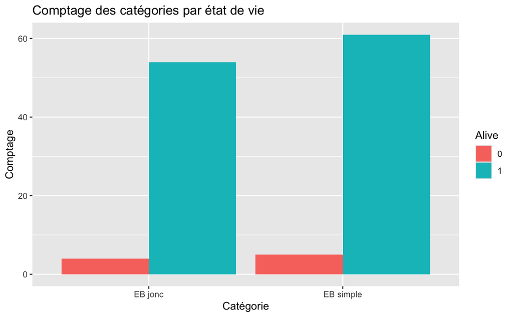

```r
# Créer un graphique de comptage avec ggplot2
ggplot(patients_EB, aes(x = categorie, fill = alive)) +
  geom_bar(position = "dodge") +
  labs(x = "Catégorie", y = "Comptage", fill = "Alive") +
  ggtitle("Comptage des catégories par état de vie")
```

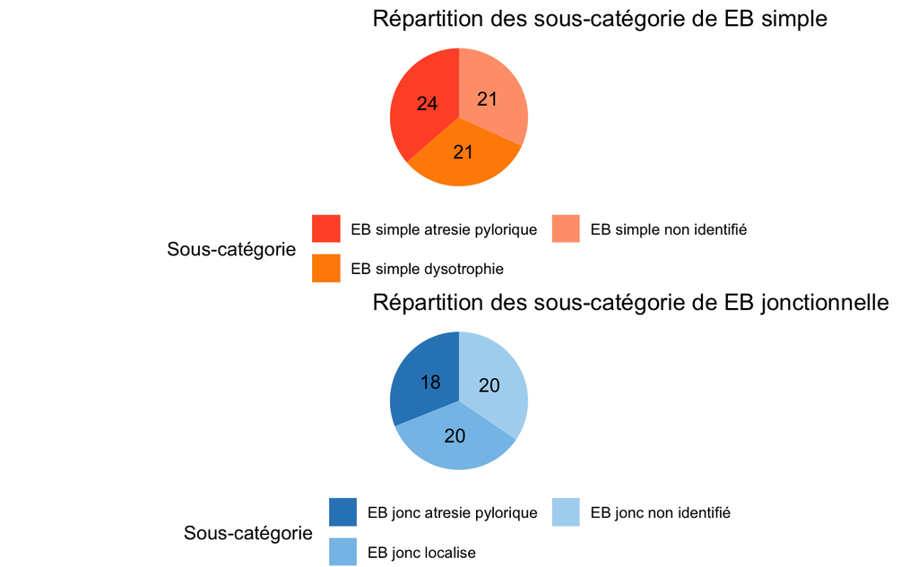

```r
# Données
modalites_counts_simple <- table(patients_EB$sous_categorie[patients_EB$categorie == "EB simple"])
modalites_counts_jonc <- table(patients_EB$sous_categorie[patients_EB$categorie == "EB jonc"])

# Diagramme circulaire pour la catégorie "EB simple" avec étiquettes numériques
pie_simple <- ggplot(data = data.frame(modalites_counts_simple), aes(x = "", y = Freq, fill = factor(Var1), label = Freq)) +
  geom_bar(stat = "identity", width = 1) +
  geom_text(aes(label = Freq), position = position_stack(vjust = 0.5)) +  # Ajouter les étiquettes numériques
  coord_polar("y", start = 0) +
  theme_void() +
  theme(legend.position = "bottom") +
  scale_fill_manual(values = c('#FF5733', '#FF8C00', '#FFA07A', '#FF6347', '#FF4500')) +
  labs(title = "Répartition des sous-catégorie de EB simple", fill = "Sous-catégorie") +
  guides(fill = guide_legend(nrow = 2))  # Définir le nombre de lignes dans la légende

# Diagramme circulaire pour la catégorie "EB jonctionnelle" avec étiquettes numériques
pie_jonc <- ggplot(data = data.frame(modalites_counts_jonc), aes(x = "", y = Freq, fill = factor(Var1), label = Freq)) +
  geom_bar(stat = "identity", width = 1) +
  geom_text(aes(label = Freq), position = position_stack(vjust = 0.5)) +  # Ajouter les étiquettes numériques
  coord_polar("y", start = 0) +
  theme_void() +
  theme(legend.position = "bottom") +
  scale_fill_manual(values = c('#2E86C1', '#85C1E9', '#AED6F1', '#D6EAF8', '#EBF5FB')) +
  labs(title = "Répartition des sous-catégorie de EB jonctionnelle", fill = "Sous-catégorie") +
  guides(fill = guide_legend(nrow = 2))  # Définir le nombre de lignes dans la légende

# Afficher les deux diagrammes circulaires côte à côte
cowplot::plot_grid(pie_simple, pie_jonc, ncol = 1)
```

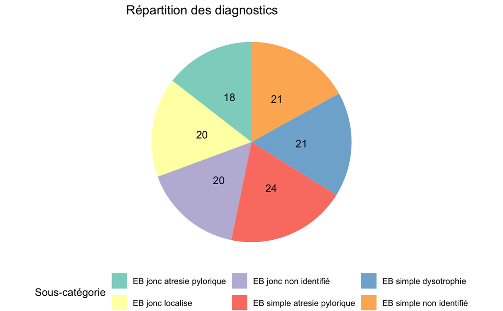

```r
# Données
modalites_counts <- table(patients_EB$sous_categorie)

# Répartition de la population selon les sous-catégories
pie_chart <- ggplot(data = data.frame(modalites_counts), aes(x = "", y = Freq, fill = factor(Var1), label = Freq)) +
  geom_bar(stat = "identity", width = 1) +
  geom_text(aes(label = Freq), position = position_stack(vjust = 0.5)) +  # Ajouter les étiquettes numériques
  coord_polar("y", start = 0) +
  theme_void() +
  theme(legend.position = "bottom") +
  labs(title = "Répartition des diagnostics", fill = "Sous-catégorie") +
  scale_fill_brewer(palette = "Set3")  # Vous pouvez remplacer "Set3" par le nom de la palette de couleurs de votre choix

# Afficher le diagramme circulaire
pie_chart
```

```r
# Créer la table de contingence
diagnostic_alive <- table(patients_EB$diagnostic, patients_EB$alive)

# Effectuer le test du Chi carré
test_chi2 <- chisq.test(diagnostic_alive)
# Afficher les résultats
print(test_chi2)
```

```
    Pearson's Chi-squared test

data:  diagnostic_alive
X-squared = 11.377, df = 5, p-value = 0.0444
```

On constate que la p-valeur est inférieur à 0.05 donc il existe une association significative entre les variables “diagnostic” et “alive”.

##### Analyse entre le niveau et le diagnostic

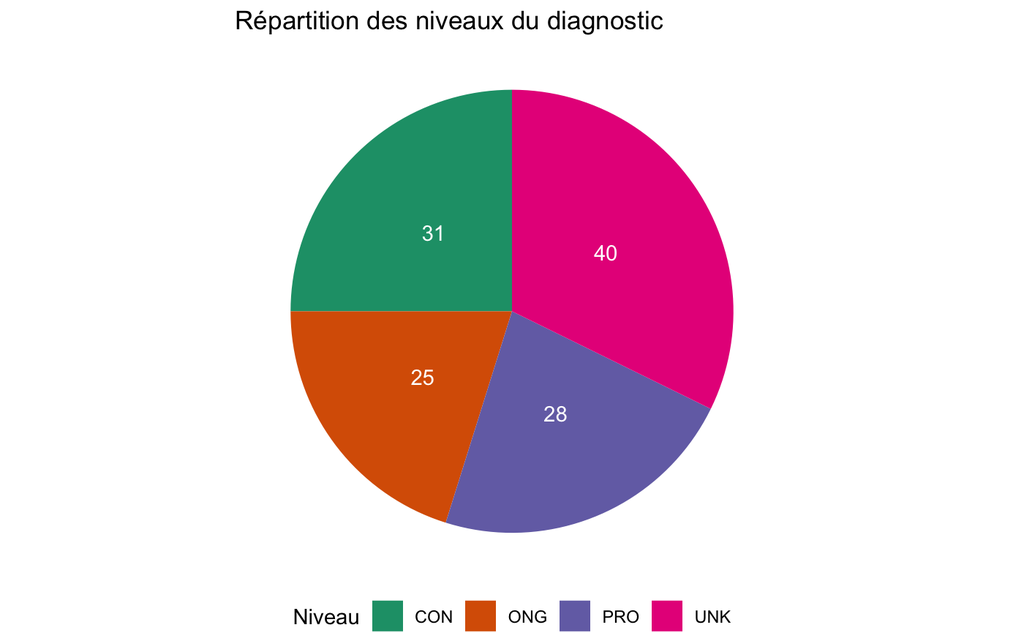

```r
# Données
modalites_counts <- table(patients_EB$level)

# Répartition des niveaux
pie_chart <- ggplot(data = data.frame(modalites_counts), aes(x = "", y = Freq, fill = factor(Var1), label = Freq)) +
  geom_bar(stat = "identity", width = 1) +
  geom_text(aes(label = Freq), position = position_stack(vjust = 0.5), color = "white") +  # Ajouter les étiquettes numériques
  coord_polar("y", start = 0) +
  theme_void() +
  theme(legend.position = "bottom") +
  labs(title = "Répartition des niveaux du diagnostic", fill = "Niveau") +
  scale_fill_brewer(palette = "Dark2")  # Utiliser la palette Dark2 de RColorBrewer

# Afficher le diagramme circulaire
pie_chart
```

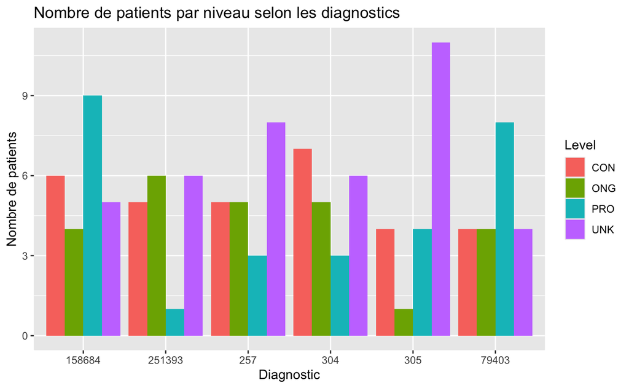

```r
# Créer un graphique de comptage avec ggplot2
ggplot(patients_EB, aes(x = diagnostic, fill = level)) +
  geom_bar(position = "dodge") +
  labs(x = "Diagnostic", y = "Nombre de patients", fill = "Level") +
  ggtitle("Nombre de patients par niveau selon les diagnostics")
```

```r
# Créer la table de contingence
diagnostics_level <- table(patients_EB$sous_categorie, patients_EB$level)

# Effectuer le test du Chi carré
test_chi2 <- chisq.test(diagnostics_level)
# Afficher les résultats
print(test_chi2)
```

```
    Pearson's Chi-squared test

data:  diagnostics_level
X-squared = 19.432, df = 15, p-value = 0.1948
```

##### Analyse entre l’âge du patient et le diagnostic

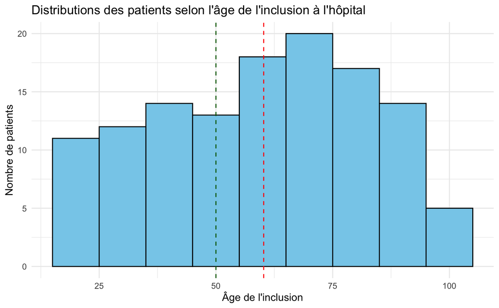

```r
# Créer un histogramme avec ggplot2
ggplot(patients_EB, aes(x = age_inclusion)) +
  geom_histogram(binwidth = 10, fill = "skyblue", color = "black") +
  ggtitle("Distributions des patients selon l'âge de l'inclusion à l'hôpital") +
  labs(x = "Âge de l'inclusion", y = "Nombre de patients") +
  geom_vline(xintercept = mean(patients_EB$age_inclusion), color = "red", linetype = "dashed") +
  geom_vline(xintercept = 50, color = "darkgreen", linetype = "dashed") +
  theme_minimal()
```

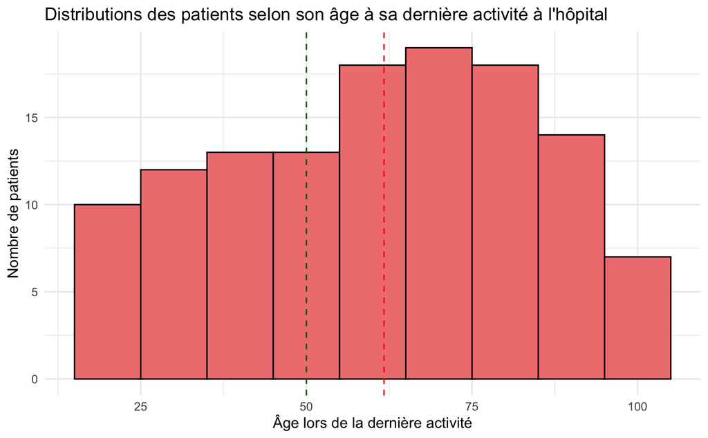

```r
# Créer un histogramme avec ggplot2
ggplot(patients_EB, aes(x = age_last_activity)) +
  geom_histogram(binwidth = 10, fill = "lightcoral", color = "black") +
  ggtitle("Distributions des patients selon son âge à sa dernière activité à l'hôpital") +
  labs(x = "Âge lors de la dernière activité", y = "Nombre de patients") +
  geom_vline(xintercept = mean(patients_EB$age_last_activity), color = "red", linetype = "dashed") +
  geom_vline(xintercept = 50, color = "darkgreen", linetype = "dashed") +
  theme_minimal()
```

```r
# Classer les patients selon s'ils ont plus ou moins de 50 ans lors de leur dernière activité
patients_EB <- patients_EB %>%
  mutate(last_activity_50 = ifelse(age_last_activity < 50, "Moins de 50 ans", "Plus de 50 ans"))

# Classer les patients selon s'ils ont plus ou moins de 50 ans lors de leur inclusion
patients_EB <- patients_EB %>%
  mutate(inclusion_50 = ifelse(age_inclusion < 50, "Moins de 50 ans", "Plus de 50 ans"))
```

```r
# Table de contingence entre 'sous-catégorie' et 'inclusion_50'
table_inclusion <- table(patients_EB$sous_categorie, patients_EB$inclusion_50)

# Afficher la table de contingence
print("Table de contingence entre 'sous-catégorie' et 'inclusion_50':")
```

```
[1] "Table de contingence entre 'sous-catégorie' et 'inclusion_50':"
```

```r
print(table_inclusion)
```

```
                              Moins de 50 ans Plus de 50 ans
  EB jonc atresie pylorique                 5             13
  EB jonc localise                          7             13
  EB jonc non identifié                     7             13
  EB simple atresie pylorique               6             18
  EB simple dysotrophie                     7             14
  EB simple non identifié                   9             12
```

```r
cat("\n")
```

```r
# Table de contingence entre 'sous-catégorie' et 'last_activity_50'
table_last_activity <- table(patients_EB$sous_categorie, patients_EB$last_activity_50)

# Afficher la table de contingence
print("Table de contingence entre 'sous-catégorie' et 'last_activity_50':")
```

```
[1] "Table de contingence entre 'sous-catégorie' et 'last_activity_50':"
```

```r
print(table_last_activity)
```

```
                              Moins de 50 ans Plus de 50 ans
  EB jonc atresie pylorique                 5             13
  EB jonc localise                          6             14
  EB jonc non identifié                     7             13
  EB simple atresie pylorique               6             18
  EB simple dysotrophie                     7             14
  EB simple non identifié                   9             12
```

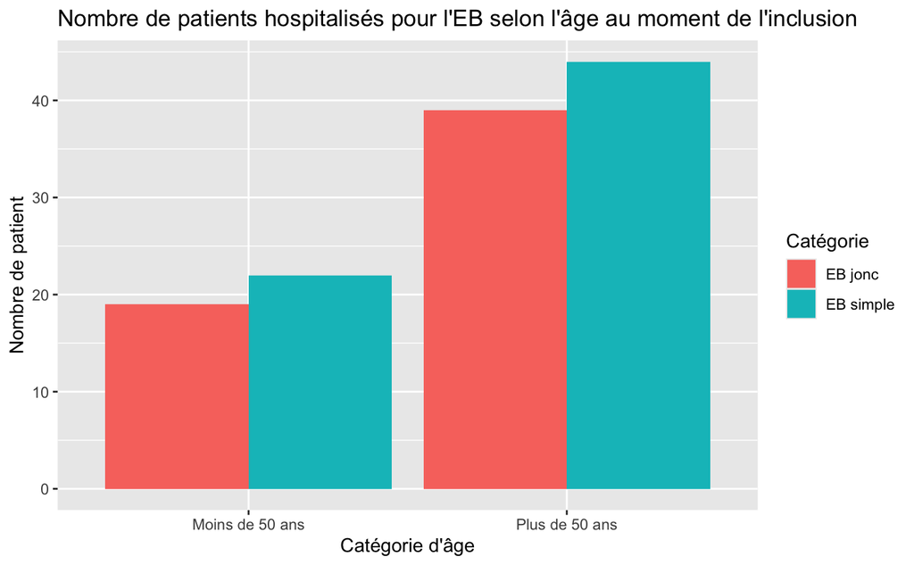

```r
# Créer un graphique de comptage avec ggplot2
ggplot(patients_EB, aes(x = inclusion_50, fill = categorie)) +
  geom_bar(position = "dodge") +
  labs(x = "Catégorie d'âge", y = "Nombre de patient", fill = "Catégorie") +
  ggtitle("Nombre de patients hospitalisés pour l'EB selon l'âge au moment de l'inclusion")
```

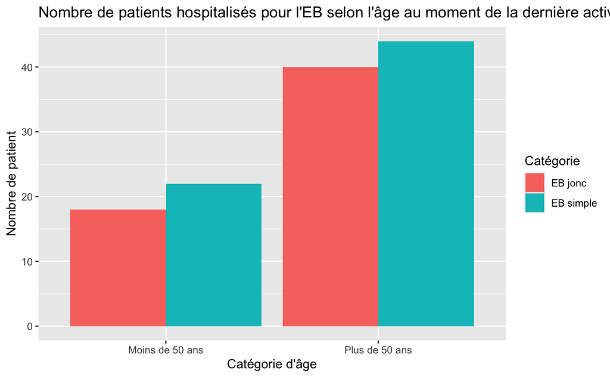

```r
ggplot(patients_EB, aes(x = last_activity_50, fill = categorie)) +
  geom_bar(position = "dodge") +
  labs(x = "Catégorie d'âge", y = "Nombre de patient", fill = "Catégorie") +
  ggtitle("Nombre de patients hospitalisés pour l'EB selon l'âge au moment de la dernière activité")
```

```r
# Calculer la durée moyenne des patients à l'hôpital
duree_moyenne <- mean(patients_EB$durée)
print(paste("La durée moyenne des patients à l'hôpital est de", duree_moyenne, "jours."))
```

```
[1] "La durée moyenne des patients à l'hôpital est de 551.112903225806 jours."
```

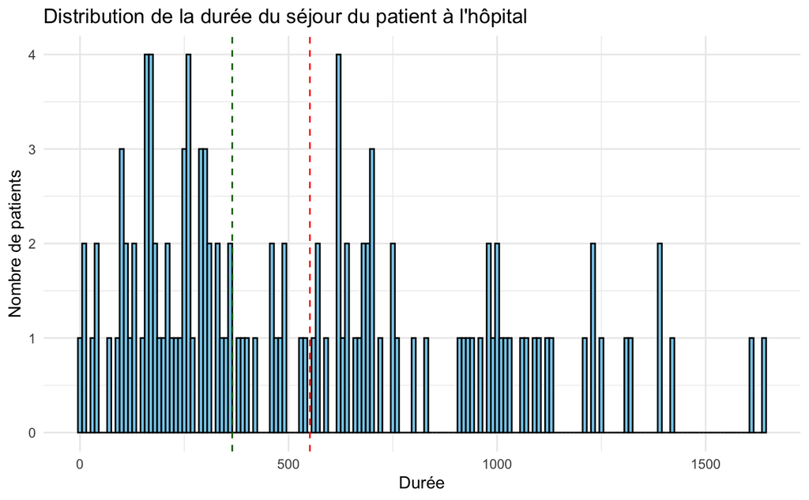

```r
# Créer un histogramme avec ggplot2
ggplot(patients_EB, aes(x = durée)) +
  geom_histogram(binwidth = 10, fill = "skyblue", color = "black") +
  ggtitle("Distribution de la durée du séjour du patient à l'hôpital") +
  labs(x = "Durée", y = "Nombre de patients") +
  geom_vline(xintercept = mean(patients_EB$durée), color = "red", linetype = "dashed") +
  geom_vline(xintercept = 365, color = "darkgreen", linetype = "dashed") +
  theme_minimal()
```

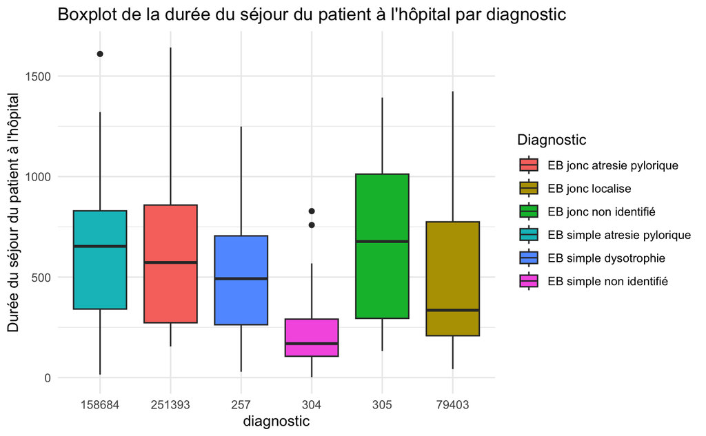

```r
ggplot(patients_EB, aes(x = diagnostic, y = durée, fill = sous_categorie)) +
  geom_boxplot() +
  ggtitle("Boxplot de la durée du séjour du patient à l'hôpital par diagnostic") +
  labs(y = "Durée du séjour du patient à l'hôpital", fill = "Diagnostic") +
  theme_minimal()
```